# Predictive modeling of customer bookings via Buying Behaviour

### Exploratory data analysis

First, we must explore the data in order to better understand what we have and the statistical properties of the dataset.

```python
import pandas as pd
```

```python
df = pd.read_csv("customer_booking.csv", encoding="ISO-8859-1")
df.head()
```

|  | num_passengers | sales_channel | trip_type | purchase_lead | length_of_stay | flight_hour | flight_day | route | booking_origin | wants_extra_baggage | wants_preferred_seat | wants_in_flight_meals | flight_duration | booking_complete |
| --- | --- | --- | --- | --- | --- | --- | --- | --- | --- | --- | --- | --- | --- | --- |
| 0 | 2 | Internet | RoundTrip | 262 | 19 | 7 | Sat | AKLDEL | New Zealand | 1 | 0 | 0 | 5.52 | 0 |
| 1 | 1 | Internet | RoundTrip | 112 | 20 | 3 | Sat | AKLDEL | New Zealand | 0 | 0 | 0 | 5.52 | 0 |
| 2 | 2 | Internet | RoundTrip | 243 | 22 | 17 | Wed | AKLDEL | India | 1 | 1 | 0 | 5.52 | 0 |
| 3 | 1 | Internet | RoundTrip | 96 | 31 | 4 | Sat | AKLDEL | New Zealand | 0 | 0 | 1 | 5.52 | 0 |
| 4 | 2 | Internet | RoundTrip | 68 | 22 | 15 | Wed | AKLDEL | India | 1 | 0 | 1 | 5.52 | 0 |

The `.head()` method allows us to view the first 5 rows in the dataset, this is useful for visual inspection of our columns

```python
df.info()
```

```
<class 'pandas.core.frame.DataFrame'>
RangeIndex: 50000 entries, 0 to 49999
Data columns (total 14 columns):
 #   Column                 Non-Null Count  Dtype
---  ------                 --------------  -----
 0   num_passengers         50000 non-null  int64
 1   sales_channel          50000 non-null  object
 2   trip_type              50000 non-null  object
 3   purchase_lead          50000 non-null  int64
 4   length_of_stay         50000 non-null  int64
 5   flight_hour            50000 non-null  int64
 6   flight_day             50000 non-null  object
 7   route                  50000 non-null  object
 8   booking_origin         50000 non-null  object
 9   wants_extra_baggage    50000 non-null  int64
 10  wants_preferred_seat   50000 non-null  int64
 11  wants_in_flight_meals  50000 non-null  int64
 12  flight_duration        50000 non-null  float64
 13  booking_complete       50000 non-null  int64
dtypes: float64(1), int64(8), object(5)
memory usage: 5.3+ MB
```

The `.info()` method gives us a data description, telling us the names of the columns, their data types and how many null values we have. Fortunately, we have no null values. It looks like some of these columns should be converted into different data types, e.g. flight_day.

To provide more context, below is a more detailed data description, explaining exactly what each column means:

- `num_passengers` = number of passengers travelling
- `sales_channel` = sales channel booking was made on
- `trip_type` = trip Type (Round Trip, One Way, Circle Trip)
- `purchase_lead` = number of days between travel date and booking date
- `length_of_stay` = number of days spent at destination
- `flight_hour` = hour of flight departure
- `flight_day` = day of week of flight departure
- `route` = origin -> destination flight route
- `booking_origin` = country from where booking was made
- `wants_extra_baggage` = if the customer wanted extra baggage in the booking
- `wants_preferred_seat` = if the customer wanted a preferred seat in the booking
- `wants_in_flight_meals` = if the customer wanted in-flight meals in the booking
- `flight_duration` = total duration of flight (in hours)
- `booking_complete` = flag indicating if the customer completed the booking

Before we compute any statistics on the data, lets do any necessary data conversion

```python
df["flight_day"].unique()
```

```
array(['Sat', 'Wed', 'Thu', 'Mon', 'Sun', 'Tue', 'Fri'], dtype=object)
```

```python
mapping = {
    "Mon": 1,
    "Tue": 2,
    "Wed": 3,
    "Thu": 4,
    "Fri": 5,
    "Sat": 6,
    "Sun": 7,
}

df["flight_day"] = df["flight_day"].map(mapping)
```

```python
df["flight_day"].unique()
```

```
array([6, 3, 4, 1, 7, 2, 5])
```

```python
df.describe()
```

|  | num_passengers | purchase_lead | length_of_stay | flight_hour | flight_day | wants_extra_baggage | wants_preferred_seat | wants_in_flight_meals | flight_duration | booking_complete |
| --- | --- | --- | --- | --- | --- | --- | --- | --- | --- | --- |
| count | 50000.000000 | 50000.000000 | 50000.00000 | 50000.00000 | 50000.000000 | 50000.000000 | 50000.000000 | 50000.000000 | 50000.000000 | 50000.000000 |
| mean | 1.591240 | 84.940480 | 23.04456 | 9.06634 | 3.814420 | 0.668780 | 0.296960 | 0.427140 | 7.277561 | 0.149560 |
| std | 1.020165 | 90.451378 | 33.88767 | 5.41266 | 1.992792 | 0.470657 | 0.456923 | 0.494668 | 1.496863 | 0.356643 |
| min | 1.000000 | 0.000000 | 0.00000 | 0.00000 | 1.000000 | 0.000000 | 0.000000 | 0.000000 | 4.670000 | 0.000000 |
| 25% | 1.000000 | 21.000000 | 5.00000 | 5.00000 | 2.000000 | 0.000000 | 0.000000 | 0.000000 | 5.620000 | 0.000000 |
| 50% | 1.000000 | 51.000000 | 17.00000 | 9.00000 | 4.000000 | 1.000000 | 0.000000 | 0.000000 | 7.570000 | 0.000000 |
| 75% | 2.000000 | 115.000000 | 28.00000 | 13.00000 | 5.000000 | 1.000000 | 1.000000 | 1.000000 | 8.830000 | 0.000000 |
| max | 9.000000 | 867.000000 | 778.00000 | 23.00000 | 7.000000 | 1.000000 | 1.000000 | 1.000000 | 9.500000 | 1.000000 |

The `.describe()` method gives us a summary of descriptive statistics over the entire dataset (only works for numeric columns). This gives us a quick overview of a few things such as the mean, min, max and overall distribution of each column.

From this point, you should continue exploring the dataset with some visualisations and other metrics that you think may be useful. Then, you should prepare your dataset for predictive modelling. Finally, you should train your machine learning model, evaluate it with performance metrics and output visualisations for the contributing variables. All of this analysis should be summarised in your single slide.

```python
df
```

|  | num_passengers | sales_channel | trip_type | purchase_lead | length_of_stay | flight_hour | flight_day | route | booking_origin | wants_extra_baggage | wants_preferred_seat | wants_in_flight_meals | flight_duration | booking_complete |
| --- | --- | --- | --- | --- | --- | --- | --- | --- | --- | --- | --- | --- | --- | --- |
| 0 | 2 | Internet | RoundTrip | 262 | 19 | 7 | 6 | AKLDEL | New Zealand | 1 | 0 | 0 | 5.52 | 0 |
| 1 | 1 | Internet | RoundTrip | 112 | 20 | 3 | 6 | AKLDEL | New Zealand | 0 | 0 | 0 | 5.52 | 0 |
| 2 | 2 | Internet | RoundTrip | 243 | 22 | 17 | 3 | AKLDEL | India | 1 | 1 | 0 | 5.52 | 0 |
| 3 | 1 | Internet | RoundTrip | 96 | 31 | 4 | 6 | AKLDEL | New Zealand | 0 | 0 | 1 | 5.52 | 0 |
| 4 | 2 | Internet | RoundTrip | 68 | 22 | 15 | 3 | AKLDEL | India | 1 | 0 | 1 | 5.52 | 0 |
| ... | ... | ... | ... | ... | ... | ... | ... | ... | ... | ... | ... | ... | ... | ... |
| 49995 | 2 | Internet | RoundTrip | 27 | 6 | 9 | 6 | PERPNH | Australia | 1 | 0 | 1 | 5.62 | 0 |
| 49996 | 1 | Internet | RoundTrip | 111 | 6 | 4 | 7 | PERPNH | Australia | 0 | 0 | 0 | 5.62 | 0 |
| 49997 | 1 | Internet | RoundTrip | 24 | 6 | 22 | 6 | PERPNH | Australia | 0 | 0 | 1 | 5.62 | 0 |
| 49998 | 1 | Internet | RoundTrip | 15 | 6 | 11 | 1 | PERPNH | Australia | 1 | 0 | 1 | 5.62 | 0 |
| 49999 | 1 | Internet | RoundTrip | 19 | 6 | 10 | 4 | PERPNH | Australia | 0 | 1 | 0 | 5.62 | 0 |

50000 rows × 14 columns

### Import Libraries

```python
import pandas as pd
import numpy as np
import seaborn as sns
import matplotlib.pyplot as plt
```

```python
# Sklearn modules for preprocessing and model selection
from sklearn.model_selection import train_test_split,GridSearchCV,cross_val_score,StratifiedKFold
from sklearn.preprocessing import StandardScaler,LabelEncoder,OneHotEncoder
from sklearn.compose import ColumnTransformer
from sklearn.pipeline import Pipeline
from sklearn.impute import SimpleImputer
from sklearn.metrics import (accuracy_score,precision_score,recall_score,f1_score,roc_auc_score,confusion_matrix,classification_report,roc_curve)
```

```python
# Classification Algorithms
from sklearn.linear_model import LogisticRegression
from sklearn.neighbors import KNeighborsClassifier
from sklearn.svm import SVC
from sklearn.naive_bayes import GaussianNB
from sklearn.tree import DecisionTreeClassifier
from sklearn.ensemble import RandomForestClassifier,GradientBoostingClassifier,AdaBoostClassifier
```

```python
import warnings
warnings.filterwarnings("ignore") # Ignore warnings for cleaner output
```

### Data Loading

```python
def load_and_explore_data(df):
    """
    Loads and performs initial exploration
    """

    print("----- Loading Data -----")
    # Using "ISO-8859-1" encoding as some datasets contain special characters

    try:
        df = pd.read_csv("customer_booking.csv", encoding="ISO-8859-1")
    except:
        df = pd.read_csv("customer_booking.csv") # Falls back to default


    print(f"Data Shape: {df.shape}")
    print("---- Data Information -----")
    print(df.info())




    return df
```

```python
load_data = load_and_explore_data(df)
print(load_data)
```

```
----- Loading Data -----
Data Shape: (50000, 14)
---- Data Information -----
<class 'pandas.core.frame.DataFrame'>
RangeIndex: 50000 entries, 0 to 49999
Data columns (total 14 columns):
 #   Column                 Non-Null Count  Dtype
---  ------                 --------------  -----
 0   num_passengers         50000 non-null  int64
 1   sales_channel          50000 non-null  object
 2   trip_type              50000 non-null  object
 3   purchase_lead          50000 non-null  int64
 4   length_of_stay         50000 non-null  int64
 5   flight_hour            50000 non-null  int64
 6   flight_day             50000 non-null  object
```

[output cut: 63 more lines]

### Exploartory Data Analysis

```python
def visualize_data(df):
    # Create viualization to understand data distribution

    print("----- Generating Visualizations (Before Processing) -----")

    # 1. Target Variable Distribution
    plt.figure(figsize=(6,4))
    sns.countplot(x="booking_complete", data=df, palette="viridis")
    plt.title("Distribution of Target Variable (Booking Complete)")
    plt.xlabel("Booking Complete (0=No, 1=Yes)")
    plt.ylabel("Count")
    plt.show()

    # 2. Numerical Features Histograms
    numerical_cols = df.select_dtypes(include=["int64","float64"]).columns
    df[numerical_cols].hist(figsize=(12,10),bins=20,color="skyblue",edgecolor="black")
    plt.suptitle("Histograms of Numerical Features")
    plt.show()

    # 3. Correlation Matrix (Numerical Only)
    plt.figure(figsize=(12,10))
    # Select only numeric columns for correlation
    numerical_df = df.select_dtypes(include=[np.number])
    corr_matrix = numerical_df.corr()
    sns.heatmap(corr_matrix,annot=True,cmap="coolwarm", fmt=".2f",linewidths=0.5)
    plt.title("Correlation Heatmap")
    plt.show()

    # 4. Flight Day vs Booking
    plt.figure(figsize=(10,5))
    sns.countplot(x='flight_day', hue='booking_complete', data=df,
                  order=['Mon', 'Tue', 'Wed', 'Thu', 'Fri', 'Sat', 'Sun'])
    plt.title("Booking Completion by Flight Day")
    plt.show()
```

```
----- Generating Visualizations (Before Processing) -----
```

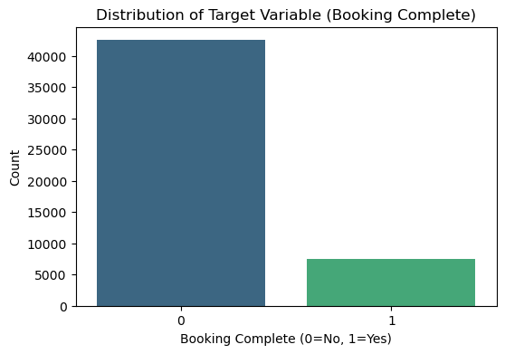

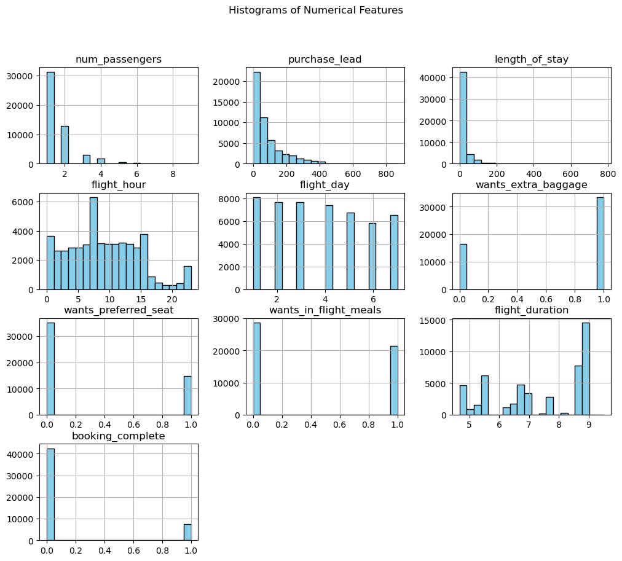

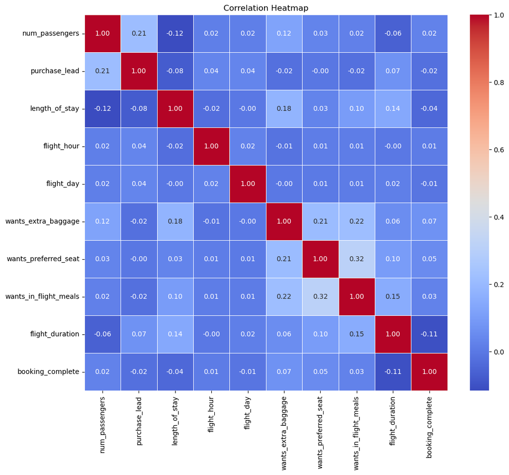

[figure not shown]

```
None
```

```python
visualizations = visualize_data(df)
print(visualizations)
```

### Data Cleaning

```python
df
```

|  | num_passengers | sales_channel | trip_type | purchase_lead | length_of_stay | flight_hour | flight_day | route | booking_origin | wants_extra_baggage | wants_preferred_seat | wants_in_flight_meals | flight_duration | booking_complete |
| --- | --- | --- | --- | --- | --- | --- | --- | --- | --- | --- | --- | --- | --- | --- |
| 0 | 2 | Internet | RoundTrip | 262 | 19 | 7 | 6 | AKLDEL | New Zealand | 1 | 0 | 0 | 5.52 | 0 |
| 1 | 1 | Internet | RoundTrip | 112 | 20 | 3 | 6 | AKLDEL | New Zealand | 0 | 0 | 0 | 5.52 | 0 |
| 2 | 2 | Internet | RoundTrip | 243 | 22 | 17 | 3 | AKLDEL | India | 1 | 1 | 0 | 5.52 | 0 |
| 3 | 1 | Internet | RoundTrip | 96 | 31 | 4 | 6 | AKLDEL | New Zealand | 0 | 0 | 1 | 5.52 | 0 |
| 4 | 2 | Internet | RoundTrip | 68 | 22 | 15 | 3 | AKLDEL | India | 1 | 0 | 1 | 5.52 | 0 |
| ... | ... | ... | ... | ... | ... | ... | ... | ... | ... | ... | ... | ... | ... | ... |
| 49995 | 2 | Internet | RoundTrip | 27 | 6 | 9 | 6 | PERPNH | Australia | 1 | 0 | 1 | 5.62 | 0 |
| 49996 | 1 | Internet | RoundTrip | 111 | 6 | 4 | 7 | PERPNH | Australia | 0 | 0 | 0 | 5.62 | 0 |
| 49997 | 1 | Internet | RoundTrip | 24 | 6 | 22 | 6 | PERPNH | Australia | 0 | 0 | 1 | 5.62 | 0 |
| 49998 | 1 | Internet | RoundTrip | 15 | 6 | 11 | 1 | PERPNH | Australia | 1 | 0 | 1 | 5.62 | 0 |
| 49999 | 1 | Internet | RoundTrip | 19 | 6 | 10 | 4 | PERPNH | Australia | 0 | 1 | 0 | 5.62 | 0 |

50000 rows × 14 columns

```python
# Check for missing values
df_missing = df.isnull().sum()
print("----- Missing Values -----")
print(df_missing)
```

```
----- Missing Values -----
num_passengers           0
sales_channel            0
trip_type                0
purchase_lead            0
length_of_stay           0
flight_hour              0
flight_day               0
route                    0
booking_origin           0
wants_extra_baggage      0
wants_preferred_seat     0
wants_in_flight_meals    0
flight_duration          0
booking_complete         0
dtype: int64
```

```python
# Check for duplicated rows
df_duplicated = df.duplicated().sum()
print("----- Duplicated Values -----")
print(df_duplicated)
```

```
----- Duplicated Values -----
719
```

```python
# Drop duplicated rows
df_duplicates = df.drop_duplicates(inplace=True)
print(df_duplicates)
```

```
None
```

```python
# Check for duplicated rows again
df_duplicated = df.duplicated().sum()
print("----- Duplicated Values -----")
print(df_duplicated)
```

```
----- Duplicated Values -----
0
```

```python
df
```

|  | num_passengers | sales_channel | trip_type | purchase_lead | length_of_stay | flight_hour | flight_day | route | booking_origin | wants_extra_baggage | wants_preferred_seat | wants_in_flight_meals | flight_duration | booking_complete |
| --- | --- | --- | --- | --- | --- | --- | --- | --- | --- | --- | --- | --- | --- | --- |
| 0 | 2 | Internet | RoundTrip | 262 | 19 | 7 | 6 | AKLDEL | New Zealand | 1 | 0 | 0 | 5.52 | 0 |
| 1 | 1 | Internet | RoundTrip | 112 | 20 | 3 | 6 | AKLDEL | New Zealand | 0 | 0 | 0 | 5.52 | 0 |
| 2 | 2 | Internet | RoundTrip | 243 | 22 | 17 | 3 | AKLDEL | India | 1 | 1 | 0 | 5.52 | 0 |
| 3 | 1 | Internet | RoundTrip | 96 | 31 | 4 | 6 | AKLDEL | New Zealand | 0 | 0 | 1 | 5.52 | 0 |
| 4 | 2 | Internet | RoundTrip | 68 | 22 | 15 | 3 | AKLDEL | India | 1 | 0 | 1 | 5.52 | 0 |
| ... | ... | ... | ... | ... | ... | ... | ... | ... | ... | ... | ... | ... | ... | ... |
| 49995 | 2 | Internet | RoundTrip | 27 | 6 | 9 | 6 | PERPNH | Australia | 1 | 0 | 1 | 5.62 | 0 |
| 49996 | 1 | Internet | RoundTrip | 111 | 6 | 4 | 7 | PERPNH | Australia | 0 | 0 | 0 | 5.62 | 0 |
| 49997 | 1 | Internet | RoundTrip | 24 | 6 | 22 | 6 | PERPNH | Australia | 0 | 0 | 1 | 5.62 | 0 |
| 49998 | 1 | Internet | RoundTrip | 15 | 6 | 11 | 1 | PERPNH | Australia | 1 | 0 | 1 | 5.62 | 0 |
| 49999 | 1 | Internet | RoundTrip | 19 | 6 | 10 | 4 | PERPNH | Australia | 0 | 1 | 0 | 5.62 | 0 |

49281 rows × 14 columns

```python
df_cleaned = df.to_csv("cleaned_customer_boking.csv",index=False)
print("Data Saved Successfully...............")
```

```
Data Saved Successfully...............
```

### Data Preprocessing and Feature Engineering

```python
def preprocess_data(df):
    # Cleans data, encodes categoricals, and scae features

    print("----- Preprocessing Data -----")

    # Make a copy to avoid SettingWithCopy warnings
    data = df.copy()


    # ----- Feature Engineering -----
    # Convert flight_day to numerical to ordinal
    day_mapping = {
        "Mon": 1,
        "Tue": 2,
        "Wed": 3,
        "Thu": 4,
        "Fri": 5,
        "Sat": 6,
        "Sun": 7
    }

    data["flight_day"] = data["flight_day"].map(day_mapping)

    # Handle High Cardinality Categoricals (Route, Booking Origin)
    # Strategy: Frequency Encoding (Replace category with its count/frequncy)
    # This captures the popularity of a route/origin without thousands of columns

    for col in ["route","booking_origin"]:
        freq_encoding = data[col].value_counts(normalize=True)
        data[col + "_freq"] = data[col].map(freq_encoding)


    # Drop the high cardinality columns
    data = data.drop(["route","booking_origin"],axis=1)

    # One-Hot Encoding for low cardinalitu categorical columns
    categorical_cols = ["sales_channel", "trip_type"]
    data = pd.get_dummies(data, columns=categorical_cols, drop_first=True)

    # ----- Splitting Features and Target -----
    X = data.drop("booking_complete", axis=1)
    y = data["booking_complete"]

    # ----- Scaling -----
    #  Standardize features (Mean=0, std=1) - vital for KNN, SVM and Logistic Regression
    scaler = StandardScaler()
    X_scaled = pd.DataFrame(scaler.fit_transform(X), columns=X.columns)


    return X_scaled, y, scaler,  X.columns
```

### Model Comparison, Training and Comparison

```python
def train_and_compare_models(X_train,X_test,y_train,y_test):
    # Trains multiple models and compare their performance

    print("-----Training and Comparing Models -----")

    # Define the dictionary of models
    models = {
        "Logistic Regression": LogisticRegression(random_state=42),
        "K-Nearest Neighbors": KNeighborsClassifier(),
        #"Support Vector Machine": SVC(probability=True, random_state=42), # Probability=True for ROC-AUC
        "Naive Bayes": GaussianNB(),
        "Decision Tree": DecisionTreeClassifier(random_state=42),
        "Random Forest": RandomForestClassifier(random_state=42),
        "Gradient Boosting": GradientBoostingClassifier(random_state=42),
        "AdaBoost": AdaBoostClassifier(random_state=42)
    }

    results = []

    for name, model in models.items():
        print(f"Training {name}......")

        # Train the model
        model.fit(X_train,y_train)

        # Predict
        y_pred = model.predict(X_test)

        # Probability for ROC-AUC
        if hasattr(model, "predict_proba"):
            y_prob = model.predict_proba(X_test)[:, 1]
        else:
            y_prob = model.decison_function(X_test) # For SVM if probability=False

        # Metrics
        acc = accuracy_score(y_test,y_pred)
        prec = precision_score(y_test,y_pred,zero_division=0)
        rec = recall_score(y_test,y_pred,zero_division=0)
        f1 = f1_score(y_test,y_pred,zero_division=0)
        roc = roc_auc_score(y_test,y_prob)

        results.append({
            "Model": name,
            "Accuracy": acc,
            "Precison": prec,
            "Recall": rec,
            "F1 Score": f1,
            "ROC AUC": roc
        })

    # Convert to DataFrame
    results_df = pd.DataFrame(results)
    results_df = results_df.sort_values(by="Accuracy", ascending=False) # Sort by F1 (good for imbalance data)

    print("----- Model Comparison Results -----")
    print(results_df)


    # Plot Comparison
    plt.figure(figsize=(12,6))
    sns.barplot(x="Accuracy", y="Model",data=results_df, palette="magma")
    plt.title("Model Comparison by Accuracy")
    plt.show()


    return results_df, models
```

### Hyperparamter Tuning (Random Forest)

```python
def tune_best_model(X_train,y_train):
    # Performs Grid Search on Random Forest (usually a strong performer)

    print("----- Hyperparameter Tuning (Random Forest) -----")

    param_grid = {
        "n_estimators": [50,100,200],
        "max_depth": [10,20, None],
        "min_samples_split": [2,5,10],
        "min_samples_leaf": [1,2,4]
    }

    rf = RandomForestClassifier(random_state=42)

    # 5-Fold Cross Validation
    grid_search = GridSearchCV(estimator=rf, param_grid=param_grid,
                               cv=3, n_jobs=-1, verbose=2, scoring="f1")

    grid_search.fit(X_train,y_train)

    print(f"Best Parameters: {grid_search.best_params_}")
    print(f"Best Cross-Validation F1 Score: {grid_search.best_score_:.4f}")


    return grid_search.best_estimator_
```

### Model Evaluation & Interpretation

```python
def evaluate_final_model(model, X_test, y_test, feature_names):
    # Detailed evaluation of the tuned model

    print("----- Final Model Evaluation -----")
    y_pred = model.predict(X_test)
    y_prob = model.predict_proba(X_test)[:,1]

    # Classification Report
    print("Classification Report")
    print(classification_report(y_test,y_pred))

    # Confusion Matrix Visualization
    cm = confusion_matrix(y_test,y_pred)
    plt.figure(figsize=(6,5))
    sns.heatmap(cm, annot=True, fmt="d", cmap="Blues", cbar=False)
    plt.xlabel("Predicted")
    plt.ylabel("Actual")
    plt.title("Comfusion Matrix (Tuned Random Foest)")
    plt.show()

    # Feature Importance Visualization (Basic)
    if hasattr(model, "feature_importances_"):
        importances = model.feature_importances_
        indices = np.argsort(importances)[::-1]

        plt.figure(figsize=(12,6))
        plt.title("Feature Importances (Basic Plot)")
        plt.bar(range(X_test.shape[1]), importances[indices], align="center")
        plt.xticks(range(X_test.shape[1]), [feature_names[i] for i in indices], rotation=90)
        plt.tight_layout()
        plt.show()
```

### Feature Importance

```python
def explain_feature_importance(model,feature_names):
    # Analyze and prints the contriution of features to the model
    print("="*40)
    print("FEATURE IMPORTANCE ANALYSIS")
    print("="*40)

    if not hasattr(model, "feature_importances_"):
        print("This model type does not support built-in importance")
        return


    # Create a DataFrame for better handling
    importances = model.feature_importances_
    feature_imp_df = pd.DataFrame({
        "Feature": feature_names,
        "Importance": importances
    }).sort_values(by="Importance",ascending=False)

    # 1. Top Contributors
    print("TOP 5 PREDICTORS")
    for index, row in feature_imp_df.head(5).iterrows():
        print(f"    -  {row["Feature"]}: {row["Importance"]:.4f}")


    # 2. Least Contributors
    print("BOTTOM 5 PREDICTORS")
    for index, row in feature_imp_df.tail(5).iterrows():
        print(f"    - {row["Feature"]}: {row["Importance"]:.4f}")


    # 3. Visual Analysis
    plt.figure(figsize=(12,8))
    sns.barplot(x="Importance", y="Feature", data=feature_imp_df.head(15), palette="mako")
    plt.title("Feature Importance: Top 15 Variables")
    plt.xlabel("Importance Score (Mean Decrease in Impurity)")
    plt.ylabel("Feature")
    plt.tight_layout()
    plt.show()

    # 4. Narrative
    top_feature = feature_imp_df.iloc[0]["Feature"]
    print(f"ANALYSIS SUMMARY:")
    print(f"The most influential variable is '{top_feature}'.")
    print("This suggests that this factor is the primary driver in distingushing between")
    print("customers who book and those who don't")
```

### New Prediction Input

```python
def predict_new_customer(model, scaler, feature_columns):
    print("Enter customer booking details:\n")

    new_customer = {
        'num_passengers': int(input("Number of passengers: ")),
        'purchase_lead': int(input("Days before flight booking was made: ")),
        'length_of_stay': int(input("Length of stay (days): ")),
        'flight_hour': int(input("Flight hour (0–23): ")),
        'flight_day': int(input("Flight day (0=Sun, 6=Sat): ")),
        'wants_extra_baggage': int(input("Wants extra baggage? (1=yes, 0=no): ")),
        'wants_preferred_seat': int(input("Wants preferred seat? (1=yes, 0=no): ")),
        'wants_in_flight_meals': int(input("Wants in-flight meals? (1=yes, 0=no): ")),
        'flight_duration': float(input("Flight duration (hours): ")),
        'route_freq': float(input("Route frequency (e.g., 0.005): ")),
        'booking_origin_freq': float(input("Booking origin frequency (e.g., 0.1): ")),
        'sales_channel_Mobile': int(input("Booked via Mobile? (1=yes, 0=no): ")),
        'sales_channel_Internet': int(input("Booked via Internet? (1=yes, 0=no): ")),
        'trip_type_OneWay': int(input("Trip type OneWay? (1=yes, 0=no): ")),
        'trip_type_RoundTrip': int(input("Trip type RoundTrip? (1=yes, 0=no): "))
    }


    # IMPORTANT: ENsure the input list matches the EXACT order of X_train columns
    # Create a zero-filled array
    input_data = np.zeros ((1, len(feature_columns)))
    input_df = pd.DataFrame(input_data, columns=feature_columns)

    # Fill in known values (this logic simplifies the mapping for demonstration)
    # In a production app, you would have a more robust pipeline transformer

    # Manually mapping for the example (Assuming columns match keys roughly)
    # Note: In production, use the same Pipeline used for training

    input_df['num_passengers'] = new_customer['num_passengers']
    input_df['purchase_lead'] = new_customer['purchase_lead']
    input_df['length_of_stay'] = new_customer['length_of_stay']
    input_df['flight_hour'] = new_customer['flight_hour']
    input_df['flight_day'] = new_customer['flight_day']
    input_df['wants_extra_baggage'] = new_customer['wants_extra_baggage']
    input_df['wants_preferred_seat'] = new_customer['wants_preferred_seat']
    input_df['wants_in_flight_meals'] = new_customer['wants_in_flight_meals']
    input_df['flight_duration'] = new_customer['flight_duration']

    # Handle the generated frequency columns and one-hot columns
    # We try to fill by name if they exist in the trained features
    for col in feature_columns:
        if col in new_customer:
            input_df[col] = new_customer[col]


    # Scale the input
    input_scaled = scaler.transform(input_df)

    # Predict
    prediction = model.predict(input_scaled)
    probability = model.predict_proba(input_scaled)[0][1]


    print(f"New Customer Input: {new_customer}")
    print(f"Prediction: {'Booking will be COMPLETED' if prediction[0] == 1 else 'Booking will NOT be completed'}")
    print(f"Probability of Booking: {probability:.2%}")
```

### Main Execution

```
----- Loading Data -----
Data Shape: (50000, 14)
---- Data Information -----
<class 'pandas.core.frame.DataFrame'>
RangeIndex: 50000 entries, 0 to 49999
Data columns (total 14 columns):
 #   Column                 Non-Null Count  Dtype
---  ------                 --------------  -----
 0   num_passengers         50000 non-null  int64
 1   sales_channel          50000 non-null  object
 2   trip_type              50000 non-null  object
 3   purchase_lead          50000 non-null  int64
 4   length_of_stay         50000 non-null  int64
 5   flight_hour            50000 non-null  int64
 6   flight_day             50000 non-null  object
 7   route                  50000 non-null  object
 8   booking_origin         50000 non-null  object
 9   wants_extra_baggage    50000 non-null  int64
 10  wants_preferred_seat   50000 non-null  int64
 11  wants_in_flight_meals  50000 non-null  int64
 12  flight_duration        50000 non-null  float64
 13  booking_complete       50000 non-null  int64
dtypes: float64(1), int64(8), object(5)
memory usage: 5.3+ MB
None
----- Generating Visualizations (Before Processing) -----
```

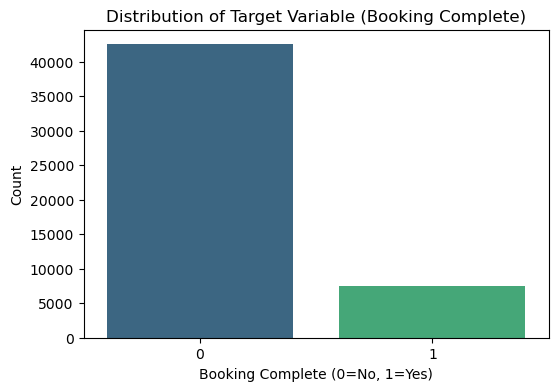

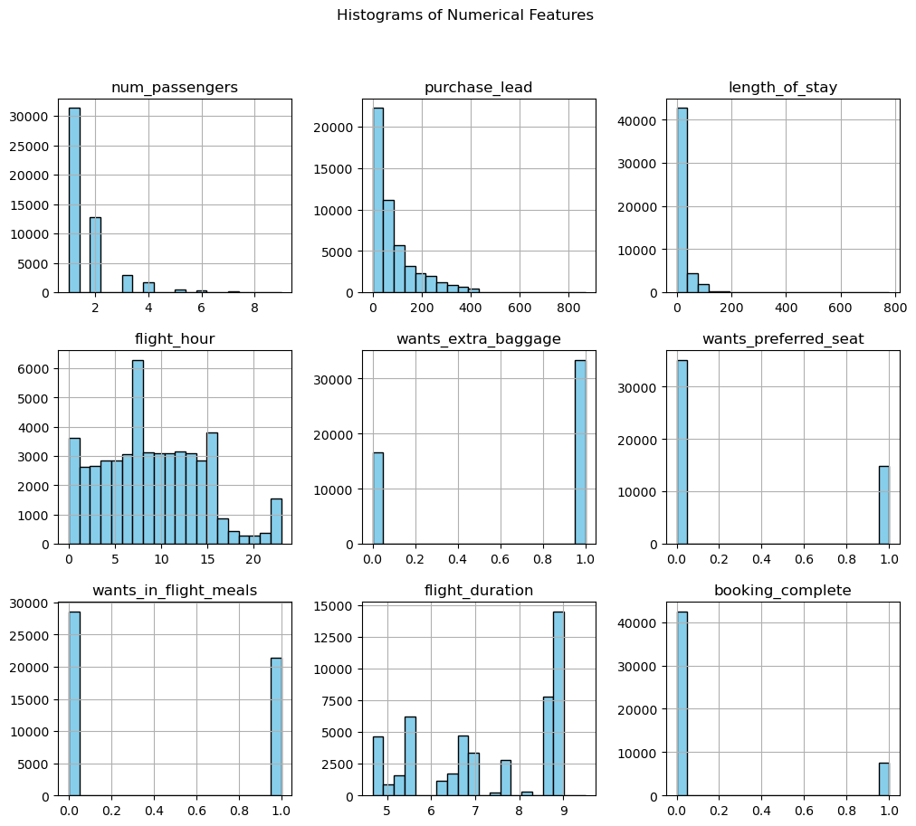

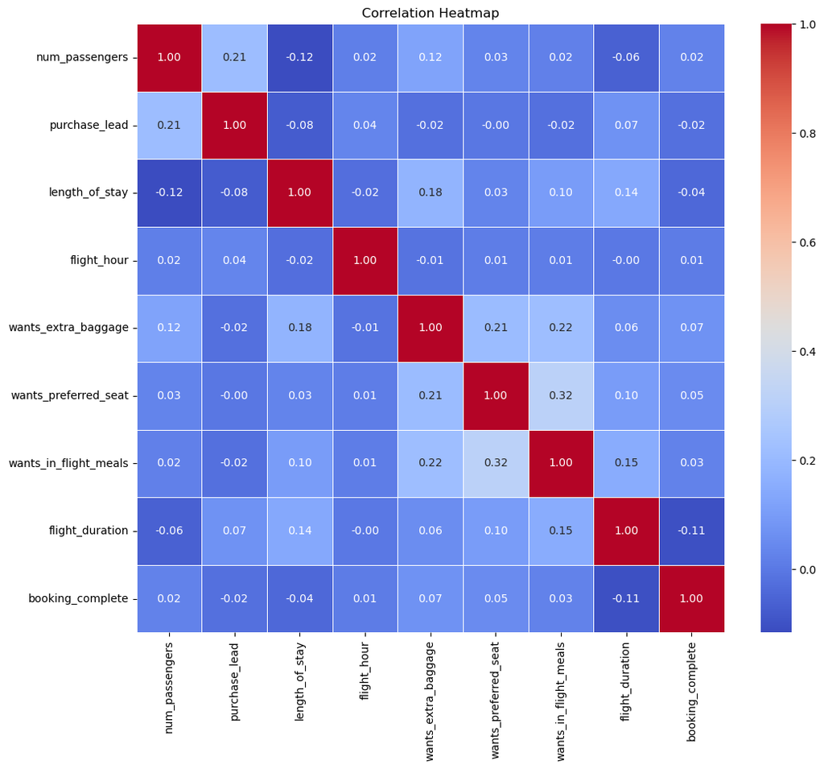

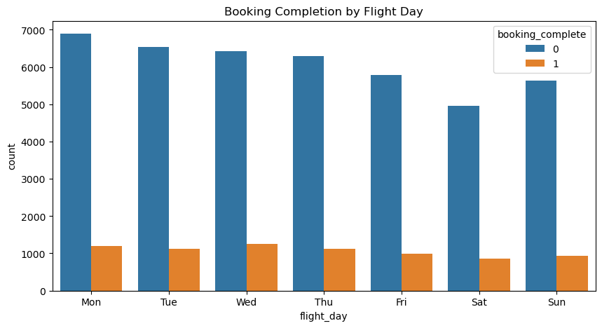

```
----- Preprocessing Data -----
Training Features Shape: (40000, 14)
Testing Features Shape: (10000, 14)
-----Training and Comparing Models -----
Training Logistic Regression......
Training K-Nearest Neighbors......
Training Naive Bayes......
Training Decision Tree......
Training Random Forest......
Training Gradient Boosting......
Training AdaBoost......
----- Model Comparison Results -----
                 Model  Accuracy  Precison    Recall  F1 Score   ROC AUC
4        Random Forest    0.8528  0.549180  0.089572  0.154023  0.769455
5    Gradient Boosting    0.8523  0.611765  0.034759  0.065781  0.772392
6             AdaBoost    0.8507  0.548387  0.011364  0.022266  0.750238
0  Logistic Regression    0.8504  0.000000  0.000000  0.000000  0.681787
1  K-Nearest Neighbors    0.8348  0.356089  0.129011  0.189401  0.637912
3        Decision Tree    0.7793  0.281500  0.306150  0.293308  0.584302
2          Naive Bayes    0.6778  0.245878  0.558155  0.341374  0.681815
```

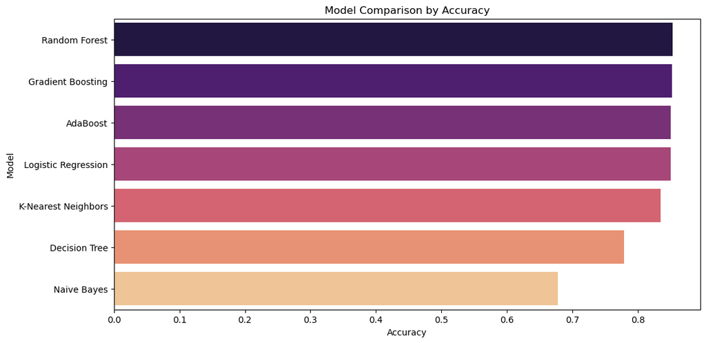

```
----- Hyperparameter Tuning (Random Forest) -----
Fitting 3 folds for each of 81 candidates, totalling 243 fits
Best Parameters: {'max_depth': None, 'min_samples_leaf': 1, 'min_samples_split': 2, 'n_estimators': 50}
Best Cross-Validation F1 Score: 0.1600
----- Final Model Evaluation -----
Classification Report
              precision    recall  f1-score   support

           0       0.86      0.99      0.92      8504
           1       0.53      0.10      0.16      1496

    accuracy                           0.85     10000
   macro avg       0.70      0.54      0.54     10000
weighted avg       0.81      0.85      0.81     10000
```

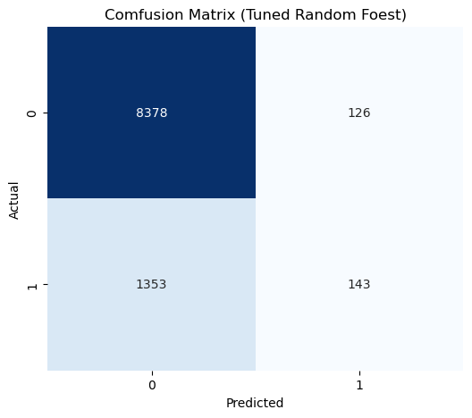

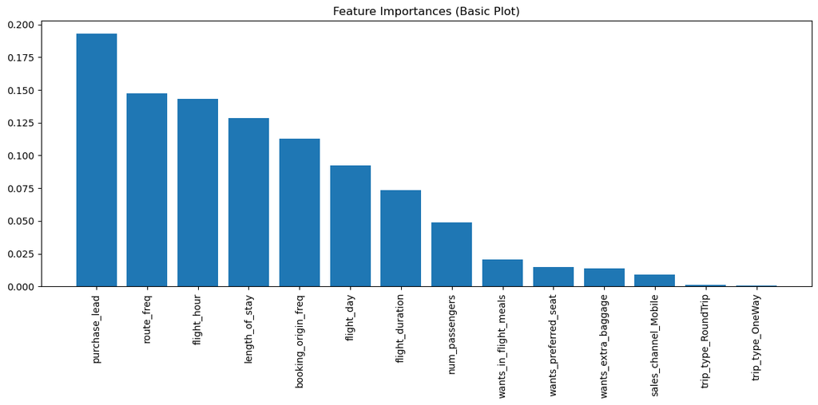

```
========================================
FEATURE IMPORTANCE ANALYSIS
========================================
TOP 5 PREDICTORS
    -  purchase_lead: 0.1931
    -  route_freq: 0.1473
    -  flight_hour: 0.1434
    -  length_of_stay: 0.1283
    -  booking_origin_freq: 0.1131
BOTTOM 5 PREDICTORS
    - wants_preferred_seat: 0.0149
    - wants_extra_baggage: 0.0136
    - sales_channel_Mobile: 0.0091
    - trip_type_RoundTrip: 0.0012
    - trip_type_OneWay: 0.0007
```

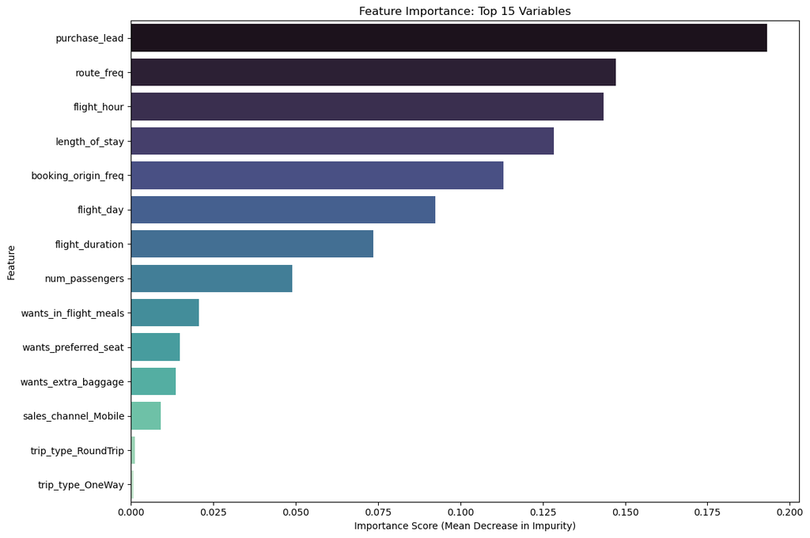

```
ANALYSIS SUMMARY:
The most influential variable is 'purchase_lead'.
This suggests that this factor is the primary driver in distingushing between
customers who book and those who don't
```

```python
if __name__ == "__main__":

    # 1. Load Data
    # Ensure 'customer_booking.csv' is in the same directory
    df = load_and_explore_data('customer_booking.csv')

    # 2. EDA
    visualize_data(df)

    # 3. Preprocessing
    X, y, scaler, feature_names = preprocess_data(df)

    # Train/Test Split (80% Train, 20% Test)
    # stratify=y ensures the class balance is maintained in splits
    X_train, X_test, y_train, y_test = train_test_split(X, y, test_size=0.2, random_state=42, stratify=y)

    print(f"Training Features Shape: {X_train.shape}")
    print(f"Testing Features Shape: {X_test.shape}")

    # 4. Compare All Models
    results_df, model_dict = train_and_compare_models(X_train, X_test, y_train, y_test)

    # 5. Hyperparameter Tuning (Focusing on Random Forest as it usually performs well on this type of data)
    best_rf_model = tune_best_model(X_train, y_train)

    # 6. Evaluate Final Model
    evaluate_final_model(best_rf_model, X_test, y_test, feature_names)

    # 7. Detailed Feature Importance Analysis (Added)
    explain_feature_importance(best_rf_model, feature_names)
```